# Raw Data

```python
from IPython.display import IFrame
IFrame('http://archive.ics.uci.edu/ml/machine-learning-databases/iris/iris.data', width=300, height=200)
```

[interactive chart not shown]

## import numpy,pandas,mpl,plt

```python
import numpy as np
import pandas as pd
import seaborn as sns
import matplotlib.pyplot as plt
%matplotlib inline
```

```python
###from sklearn.datasets import load_iris

# save load_iris() sklearn dataset to iris
# if you'd like to check dataset type use: type(load_iris())
# if you'd like to view list of attributes use: dir(load_iris())
###iris = load_iris()

# np.c_ is the numpy concatenate function
# which is used to concat iris['data'] and iris['target'] arrays
# for pandas column argument: concat iris['feature_names'] list
# and string list (in this case one string); you can make this anything you'd like..
# the original dataset would probably call this ['Species']
###df_iris = pd.DataFrame(data= np.c_[iris['data'], iris['target']],
                     ###columns= iris['feature_names'] + ['target'])
```

# Data Ingestion

```python
#df_iris
```

```python
df= pd.read_csv('Iris.csv')
```

## Data Preview

```python
df
```

|  | Id | SepalLengthCm | SepalWidthCm | PetalLengthCm | PetalWidthCm | Species |
| --- | --- | --- | --- | --- | --- | --- |
| 0 | 1 | 5.1 | 3.5 | 1.4 | 0.2 | Iris-setosa |
| 1 | 2 | 4.9 | 3.0 | 1.4 | 0.2 | Iris-setosa |
| 2 | 3 | 4.7 | 3.2 | 1.3 | 0.2 | Iris-setosa |
| 3 | 4 | 4.6 | 3.1 | 1.5 | 0.2 | Iris-setosa |
| 4 | 5 | 5.0 | 3.6 | 1.4 | 0.2 | Iris-setosa |
| 5 | 6 | 5.4 | 3.9 | 1.7 | 0.4 | Iris-setosa |
| 6 | 7 | 4.6 | 3.4 | 1.4 | 0.3 | Iris-setosa |
| 7 | 8 | 5.0 | 3.4 | 1.5 | 0.2 | Iris-setosa |
| 8 | 9 | 4.4 | 2.9 | 1.4 | 0.2 | Iris-setosa |
| 9 | 10 | 4.9 | 3.1 | 1.5 | 0.1 | Iris-setosa |
| 10 | 11 | 5.4 | 3.7 | 1.5 | 0.2 | Iris-setosa |
| 11 | 12 | 4.8 | 3.4 | 1.6 | 0.2 | Iris-setosa |
| 12 | 13 | 4.8 | 3.0 | 1.4 | 0.1 | Iris-setosa |
| 13 | 14 | 4.3 | 3.0 | 1.1 | 0.1 | Iris-setosa |
| 14 | 15 | 5.8 | 4.0 | 1.2 | 0.2 | Iris-setosa |
| 15 | 16 | 5.7 | 4.4 | 1.5 | 0.4 | Iris-setosa |
| 16 | 17 | 5.4 | 3.9 | 1.3 | 0.4 | Iris-setosa |
| 17 | 18 | 5.1 | 3.5 | 1.4 | 0.3 | Iris-setosa |
| 18 | 19 | 5.7 | 3.8 | 1.7 | 0.3 | Iris-setosa |
| 19 | 20 | 5.1 | 3.8 | 1.5 | 0.3 | Iris-setosa |
| 20 | 21 | 5.4 | 3.4 | 1.7 | 0.2 | Iris-setosa |
| 21 | 22 | 5.1 | 3.7 | 1.5 | 0.4 | Iris-setosa |
| 22 | 23 | 4.6 | 3.6 | 1.0 | 0.2 | Iris-setosa |
| 23 | 24 | 5.1 | 3.3 | 1.7 | 0.5 | Iris-setosa |
| 24 | 25 | 4.8 | 3.4 | 1.9 | 0.2 | Iris-setosa |
| 25 | 26 | 5.0 | 3.0 | 1.6 | 0.2 | Iris-setosa |
| 26 | 27 | 5.0 | 3.4 | 1.6 | 0.4 | Iris-setosa |
| 27 | 28 | 5.2 | 3.5 | 1.5 | 0.2 | Iris-setosa |
| 28 | 29 | 5.2 | 3.4 | 1.4 | 0.2 | Iris-setosa |
| 29 | 30 | 4.7 | 3.2 | 1.6 | 0.2 | Iris-setosa |
| ... | ... | ... | ... | ... | ... | ... |
| 120 | 121 | 6.9 | 3.2 | 5.7 | 2.3 | Iris-virginica |
| 121 | 122 | 5.6 | 2.8 | 4.9 | 2.0 | Iris-virginica |
| 122 | 123 | 7.7 | 2.8 | 6.7 | 2.0 | Iris-virginica |
| 123 | 124 | 6.3 | 2.7 | 4.9 | 1.8 | Iris-virginica |
| 124 | 125 | 6.7 | 3.3 | 5.7 | 2.1 | Iris-virginica |
| 125 | 126 | 7.2 | 3.2 | 6.0 | 1.8 | Iris-virginica |
| 126 | 127 | 6.2 | 2.8 | 4.8 | 1.8 | Iris-virginica |
| 127 | 128 | 6.1 | 3.0 | 4.9 | 1.8 | Iris-virginica |
| 128 | 129 | 6.4 | 2.8 | 5.6 | 2.1 | Iris-virginica |
| 129 | 130 | 7.2 | 3.0 | 5.8 | 1.6 | Iris-virginica |
| 130 | 131 | 7.4 | 2.8 | 6.1 | 1.9 | Iris-virginica |
| 131 | 132 | 7.9 | 3.8 | 6.4 | 2.0 | Iris-virginica |
| 132 | 133 | 6.4 | 2.8 | 5.6 | 2.2 | Iris-virginica |
| 133 | 134 | 6.3 | 2.8 | 5.1 | 1.5 | Iris-virginica |
| 134 | 135 | 6.1 | 2.6 | 5.6 | 1.4 | Iris-virginica |
| 135 | 136 | 7.7 | 3.0 | 6.1 | 2.3 | Iris-virginica |
| 136 | 137 | 6.3 | 3.4 | 5.6 | 2.4 | Iris-virginica |
| 137 | 138 | 6.4 | 3.1 | 5.5 | 1.8 | Iris-virginica |
| 138 | 139 | 6.0 | 3.0 | 4.8 | 1.8 | Iris-virginica |
| 139 | 140 | 6.9 | 3.1 | 5.4 | 2.1 | Iris-virginica |
| 140 | 141 | 6.7 | 3.1 | 5.6 | 2.4 | Iris-virginica |
| 141 | 142 | 6.9 | 3.1 | 5.1 | 2.3 | Iris-virginica |
| 142 | 143 | 5.8 | 2.7 | 5.1 | 1.9 | Iris-virginica |
| 143 | 144 | 6.8 | 3.2 | 5.9 | 2.3 | Iris-virginica |
| 144 | 145 | 6.7 | 3.3 | 5.7 | 2.5 | Iris-virginica |
| 145 | 146 | 6.7 | 3.0 | 5.2 | 2.3 | Iris-virginica |
| 146 | 147 | 6.3 | 2.5 | 5.0 | 1.9 | Iris-virginica |
| 147 | 148 | 6.5 | 3.0 | 5.2 | 2.0 | Iris-virginica |
| 148 | 149 | 6.2 | 3.4 | 5.4 | 2.3 | Iris-virginica |
| 149 | 150 | 5.9 | 3.0 | 5.1 | 1.8 | Iris-virginica |

150 rows × 6 columns

```python
df.info()
```

```
<class 'pandas.core.frame.DataFrame'>
RangeIndex: 150 entries, 0 to 149
Data columns (total 6 columns):
Id               150 non-null int64
SepalLengthCm    150 non-null float64
SepalWidthCm     150 non-null float64
PetalLengthCm    150 non-null float64
PetalWidthCm     150 non-null float64
Species          150 non-null object
dtypes: float64(4), int64(1), object(1)
memory usage: 7.1+ KB
```

```python
df.head()
```

|  | Id | SepalLengthCm | SepalWidthCm | PetalLengthCm | PetalWidthCm | Species |
| --- | --- | --- | --- | --- | --- | --- |
| 0 | 1 | 5.1 | 3.5 | 1.4 | 0.2 | Iris-setosa |
| 1 | 2 | 4.9 | 3.0 | 1.4 | 0.2 | Iris-setosa |
| 2 | 3 | 4.7 | 3.2 | 1.3 | 0.2 | Iris-setosa |
| 3 | 4 | 4.6 | 3.1 | 1.5 | 0.2 | Iris-setosa |
| 4 | 5 | 5.0 | 3.6 | 1.4 | 0.2 | Iris-setosa |

```python
df.describe()
```

|  | Id | SepalLengthCm | SepalWidthCm | PetalLengthCm | PetalWidthCm |
| --- | --- | --- | --- | --- | --- |
| count | 150.000000 | 150.000000 | 150.000000 | 150.000000 | 150.000000 |
| mean | 75.500000 | 5.843333 | 3.054000 | 3.758667 | 1.198667 |
| std | 43.445368 | 0.828066 | 0.433594 | 1.764420 | 0.763161 |
| min | 1.000000 | 4.300000 | 2.000000 | 1.000000 | 0.100000 |
| 25% | 38.250000 | 5.100000 | 2.800000 | 1.600000 | 0.300000 |
| 50% | 75.500000 | 5.800000 | 3.000000 | 4.350000 | 1.300000 |
| 75% | 112.750000 | 6.400000 | 3.300000 | 5.100000 | 1.800000 |
| max | 150.000000 | 7.900000 | 4.400000 | 6.900000 | 2.500000 |

```python
df['Species'].value_counts()
```

```
Iris-versicolor    50
Iris-setosa        50
Iris-virginica     50
Name: Species, dtype: int64
```

# Data Visualization

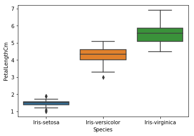

```python
# We can look at an individual feature in Seaborn through a boxplot
sns.boxplot(x='Species', y='PetalLengthCm', data=df)
```

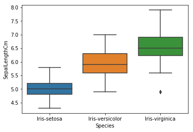

```python
# We can look at an individual feature in Seaborn through a boxplot
sns.boxplot(x='Species', y='SepalLengthCm', data=df)
```

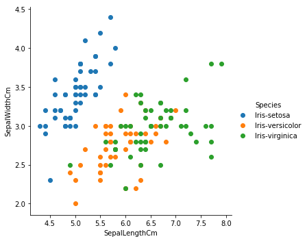

```python
# use seaborn's FacetGrid to color the scatterplot by species
sns.FacetGrid(df, hue = 'Species', size=5) \
    .map(plt.scatter, 'SepalLengthCm','SepalWidthCm') \
    .add_legend()
```

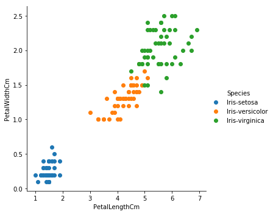

```python
# use seaborn's FacetGrid to color the scatterplot by species
sns.FacetGrid(df, hue = 'Species', size=5) \
    .map(plt.scatter, 'PetalLengthCm','PetalWidthCm') \
    .add_legend()
```

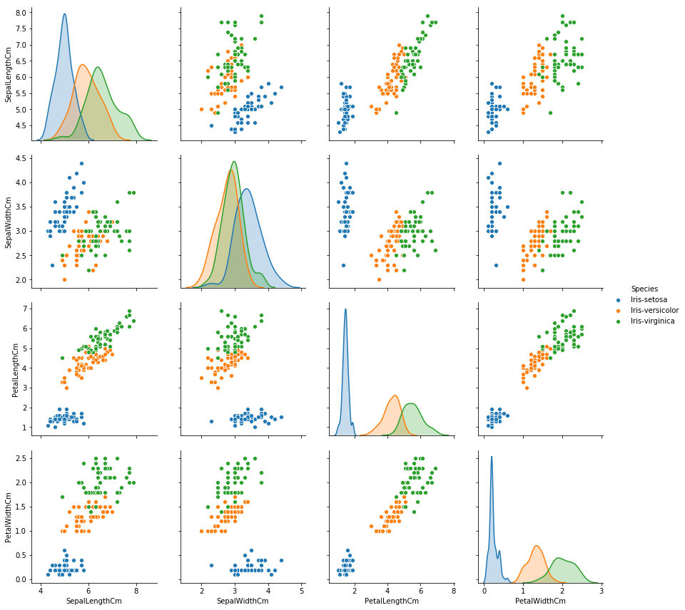

```python
sns.pairplot(df.drop('Id', axis=1), hue='Species', size=3)
# A useful seaborn plot for looking at univariate relations is the kdeplot,
# which creates and visualizes a kernel density estimate of the underlying feature
```

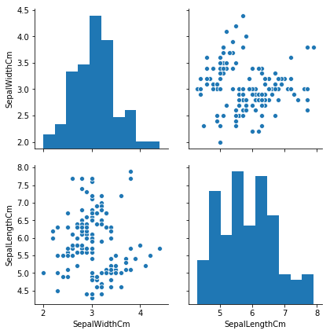

```python
g = sns.pairplot(df, height=3,vars=["SepalWidthCm", "SepalLengthCm"])
```

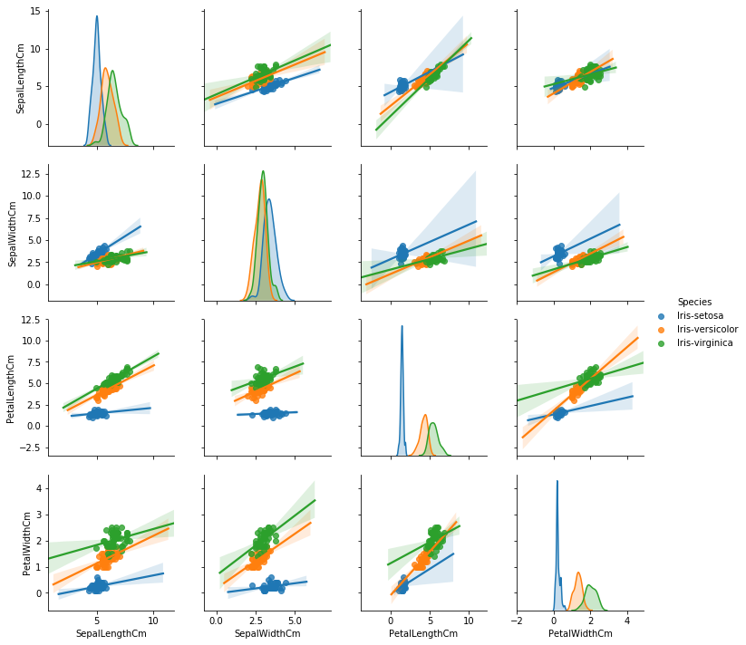

```python
g = sns.pairplot(df.drop('Id', axis=1),hue='Species', kind="reg")
```

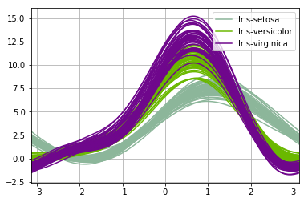

```python
# One cool more sophisticated technique pandas has available is called Andrews Curves
# Andrews Curves involve using attributes of samples as coefficients for Fourier series
# and then plotting these
from pandas.tools.plotting import andrews_curves
andrews_curves(df.drop("Id", axis=1), "Species")
```

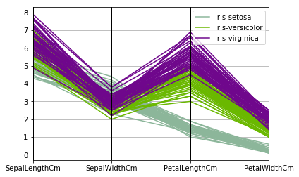

```python
# Another multivariate visualization technique pandas has is parallel_coordinates
# Parallel coordinates plots each feature on a separate column & then draws lines
# connecting the features for each data sample
from pandas.tools.plotting import parallel_coordinates
parallel_coordinates(df.drop("Id", axis=1), "Species")
```

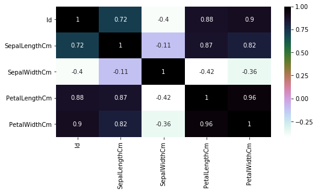

```python
plt.figure(figsize=(8,4))
sns.heatmap(df.corr(), annot=True, cmap='cubehelix_r') # draws heatmap with input as correlation matrix calculated by iris.corr()
plt.show()
```

Observation---> The Sepal Width and Length are not correlated The Petal Width and Length are highly correlated We will use all the features for training the algorithm and check the accuracy.

```python
# import load_iris function from datasets module
from sklearn.datasets import load_iris
```

```python
# save "bunch" object containing iris dataset and its attributes
iris = load_iris()
type(iris)
```

```
sklearn.utils.Bunch
```

```python
# print the iris data
print(iris.data)
```

```
[[5.1 3.5 1.4 0.2]
 [4.9 3.  1.4 0.2]
 [4.7 3.2 1.3 0.2]
 [4.6 3.1 1.5 0.2]
 [5.  3.6 1.4 0.2]
 [5.4 3.9 1.7 0.4]
 [4.6 3.4 1.4 0.3]
 [5.  3.4 1.5 0.2]
 [4.4 2.9 1.4 0.2]
 [4.9 3.1 1.5 0.1]
 [5.4 3.7 1.5 0.2]
 [4.8 3.4 1.6 0.2]
 [4.8 3.  1.4 0.1]
 [4.3 3.  1.1 0.1]
 [5.8 4.  1.2 0.2]
 [5.7 4.4 1.5 0.4]
 [5.4 3.9 1.3 0.4]
 [5.1 3.5 1.4 0.3]
 [5.7 3.8 1.7 0.3]
 [5.1 3.8 1.5 0.3]
 [5.4 3.4 1.7 0.2]
 [5.1 3.7 1.5 0.4]
 [4.6 3.6 1.  0.2]
 [5.1 3.3 1.7 0.5]
 [4.8 3.4 1.9 0.2]
 [5.  3.  1.6 0.2]
 [5.  3.4 1.6 0.4]
 [5.2 3.5 1.5 0.2]
 [5.2 3.4 1.4 0.2]
 [4.7 3.2 1.6 0.2]
 [4.8 3.1 1.6 0.2]
 [5.4 3.4 1.5 0.4]
 [5.2 4.1 1.5 0.1]
 [5.5 4.2 1.4 0.2]
 [4.9 3.1 1.5 0.1]
 [5.  3.2 1.2 0.2]
 [5.5 3.5 1.3 0.2]
 [4.9 3.1 1.5 0.1]
 [4.4 3.  1.3 0.2]
 [5.1 3.4 1.5 0.2]
```

[output cut: 95 more lines]

```
 [7.7 3.  6.1 2.3]
 [6.3 3.4 5.6 2.4]
 [6.4 3.1 5.5 1.8]
 [6.  3.  4.8 1.8]
 [6.9 3.1 5.4 2.1]
 [6.7 3.1 5.6 2.4]
 [6.9 3.1 5.1 2.3]
 [5.8 2.7 5.1 1.9]
 [6.8 3.2 5.9 2.3]
 [6.7 3.3 5.7 2.5]
 [6.7 3.  5.2 2.3]
 [6.3 2.5 5.  1.9]
 [6.5 3.  5.2 2. ]
 [6.2 3.4 5.4 2.3]
 [5.9 3.  5.1 1.8]]
```

```python
# print the names of the four features
print(iris.feature_names)
```

```
['sepal length (cm)', 'sepal width (cm)', 'petal length (cm)', 'petal width (cm)']
```

```python
# print integers representing the species of each observation
print(iris.target)
```

```
[0 0 0 0 0 0 0 0 0 0 0 0 0 0 0 0 0 0 0 0 0 0 0 0 0 0 0 0 0 0 0 0 0 0 0 0 0
 0 0 0 0 0 0 0 0 0 0 0 0 0 1 1 1 1 1 1 1 1 1 1 1 1 1 1 1 1 1 1 1 1 1 1 1 1
 1 1 1 1 1 1 1 1 1 1 1 1 1 1 1 1 1 1 1 1 1 1 1 1 1 1 2 2 2 2 2 2 2 2 2 2 2
 2 2 2 2 2 2 2 2 2 2 2 2 2 2 2 2 2 2 2 2 2 2 2 2 2 2 2 2 2 2 2 2 2 2 2 2 2
 2 2]
```

```python
# print the encoding scheme for species: 0 = setosa, 1 = versicolor, 2 = virginica
print(iris.target_names)
```

```
['setosa' 'versicolor' 'virginica']
```

```python
# check the shape of the features (first dimension = number of observations, second dimensions = number of features)
print(iris.data.shape)
```

```
(150, 4)
```

```python
# check the shape of the response (single dimension matching the number of observations)
print(iris.target.shape)
```

```
(150,)
```

```python
# store feature matrix in "X"
X = iris.data

# store response vector in "y"
y = iris.target
```

### Steps To Be followed When Applying an Algorithm

Split the dataset into training and testing dataset. The testing dataset is generally smaller than training one as it will help in training the model better.

Select any algorithm based on the problem (classification or regression) whatever you feel may be good. Then pass the training dataset to the algorithm to train it. We use the .fit() method Then pass the testing data to the trained algorithm to predict the outcome. We use the .predict() method. We then check the accuracy by passing the predicted outcome and the actual output to the model.

# scikit-learn 4-step modeling pattern

Step 1: Import the class you plan to use

```python
from sklearn.neighbors import KNeighborsClassifier
```

**Step 2:** "Instantiate" the "estimator"

- "Estimator" is scikit-learn's term for model
- "Instantiate" means "make an instance of"

```python
knn = KNeighborsClassifier(n_neighbors=1)
```

- Name of the object does not matter
- Can specify tuning parameters (aka "hyperparameters") during this step
- All parameters not specified are set to their defaults

```python
print(knn)
```

```
KNeighborsClassifier(algorithm='auto', leaf_size=30, metric='minkowski',
           metric_params=None, n_jobs=1, n_neighbors=1, p=2,
           weights='uniform')
```

**Step 3:** Fit the model with data (aka "model training")

- Model is learning the relationship between X and y
- Occurs in-place

```python
knn.fit(X, y)
```

```
KNeighborsClassifier(algorithm='auto', leaf_size=30, metric='minkowski',
           metric_params=None, n_jobs=1, n_neighbors=1, p=2,
           weights='uniform')
```

**Step 4:** Predict the response for a new observation

- New observations are called "out-of-sample" data
- Uses the information it learned during the model training process

```python
knn.predict([[3, 5, 4, 2]])
```

```
array([2])
```

- Returns a NumPy array
- Can predict for multiple observations at once

```python
X_new = [[3, 5, 4, 2], [1, 2, 1, 0]]
knn.predict(X_new)
```

```
array([2, 0])
```